# pandaTutorial

### This is panda tutorial Code Tutorial

#### Lecture 1

```python
import pandas as pd
```

```python
#read a dataset of chipote directly from URL and store results in dataframe
orders=pd.read_table("http://bit.ly/chiporders")
```

Lets see the first five rows orders.head()

```python
orders.head()
```

|  | order_id | quantity | item_name | choice_description | item_price |
| --- | --- | --- | --- | --- | --- |
| 0 | 1 | 1 | Chips and Fresh Tomato Salsa | NaN | $2.39 |
| 1 | 1 | 1 | Izze | [Clementine] | $3.39 |
| 2 | 1 | 1 | Nantucket Nectar | [Apple] | $3.39 |
| 3 | 1 | 1 | Chips and Tomatillo-Green Chili Salsa | NaN | $2.39 |
| 4 | 2 | 2 | Chicken Bowl | [Tomatillo-Red Chili Salsa (Hot), [Black Beans... | $16.98 |

Read the table of movie reviewers(modifying the default parameter value for read table)

```python
user_cols=["user_id","age","gender","occupation","zip_code"]
users=pd.read_table('http://bit.ly/movieusers',sep="|",header=None,names=user_cols)
```

Lets see the header rows

```python
users.head()
```

|  | user_id | age | gender | occupation | zip_code |
| --- | --- | --- | --- | --- | --- |
| 0 | 1 | 24 | M | technician | 85711 |
| 1 | 2 | 53 | F | other | 94043 |
| 2 | 3 | 23 | M | writer | 32067 |
| 3 | 4 | 24 | M | technician | 43537 |
| 4 | 5 | 33 | F | other | 15213 |

### How to select a pandas series from DataFrame

Read a dataset of UFO reports into a DataFrame

```python
ufo=pd.read_table("http://bit.ly/uforeports",sep=',')
```

Read csv is equivalent to read table, except it assumes a comma seprator

```python
ufo=pd.read_csv('http://bit.ly/uforeports')
```

lets examine the header

```python
ufo.head()
```

|  | City | Colors Reported | Shape Reported | State | Time |
| --- | --- | --- | --- | --- | --- |
| 0 | Ithaca | NaN | TRIANGLE | NY | 6/1/1930 22:00 |
| 1 | Willingboro | NaN | OTHER | NJ | 6/30/1930 20:00 |
| 2 | Holyoke | NaN | OVAL | CO | 2/15/1931 14:00 |
| 3 | Abilene | NaN | DISK | KS | 6/1/1931 13:00 |
| 4 | New York Worlds Fair | NaN | LIGHT | NY | 4/18/1933 19:00 |

Select city series using bracket notation

```python
ufo['City']
```

```
0                      Ithaca
1                 Willingboro
2                     Holyoke
3                     Abilene
4        New York Worlds Fair
5                 Valley City
6                 Crater Lake
7                        Alma
8                     Eklutna
9                     Hubbard
10                    Fontana
11                   Waterloo
12                     Belton
13                     Keokuk
14                  Ludington
```

[output cut: 47 more lines]

```python
ufo.City
```

```
0                      Ithaca
1                 Willingboro
2                     Holyoke
3                     Abilene
4        New York Worlds Fair
5                 Valley City
6                 Crater Lake
7                        Alma
8                     Eklutna
9                     Hubbard
10                    Fontana
11                   Waterloo
12                     Belton
13                     Keokuk
14                  Ludington
```

[output cut: 47 more lines]

Bracket notation will always work, whereas dot notation has limitations:

Dot notation doesn't work if there are spaces in the Series name Dot notation doesn't work if the Series has the same name as a DataFrame method or attribute (like 'head' or 'shape') Dot notation can't be used to define the name of a new Series (see below)

Create a new loactrion by adding city and state

```python
ufo['Location']=ufo.City+ ',' + ufo.State
```

```python
ufo.head()
```

|  | City | Colors Reported | Shape Reported | State | Time | Location |
| --- | --- | --- | --- | --- | --- | --- |
| 0 | Ithaca | NaN | TRIANGLE | NY | 6/1/1930 22:00 | Ithaca,NY |
| 1 | Willingboro | NaN | OTHER | NJ | 6/30/1930 20:00 | Willingboro,NJ |
| 2 | Holyoke | NaN | OVAL | CO | 2/15/1931 14:00 | Holyoke,CO |
| 3 | Abilene | NaN | DISK | KS | 6/1/1931 13:00 | Abilene,KS |
| 4 | New York Worlds Fair | NaN | LIGHT | NY | 4/18/1933 19:00 | New York Worlds Fair,NY |

#### Why do some pandas commands end with parentheses(others don't)

```python
movies=pd.read_csv('http://bit.ly/imdbratings')
```

Methods end with parenthesis and attributes don't

```python
movies.head()
```

|  | star_rating | title | content_rating | genre | duration | actors_list |
| --- | --- | --- | --- | --- | --- | --- |
| 0 | 9.3 | The Shawshank Redemption | R | Crime | 142 | [u'Tim Robbins', u'Morgan Freeman', u'Bob Gunt... |
| 1 | 9.2 | The Godfather | R | Crime | 175 | [u'Marlon Brando', u'Al Pacino', u'James Caan'] |
| 2 | 9.1 | The Godfather: Part II | R | Crime | 200 | [u'Al Pacino', u'Robert De Niro', u'Robert Duv... |
| 3 | 9.0 | The Dark Knight | PG-13 | Action | 152 | [u'Christian Bale', u'Heath Ledger', u'Aaron E... |
| 4 | 8.9 | Pulp Fiction | R | Crime | 154 | [u'John Travolta', u'Uma Thurman', u'Samuel L.... |

```python
movies.describe()
```

|  | star_rating | duration |
| --- | --- | --- |
| count | 979.000000 | 979.000000 |
| mean | 7.889785 | 120.979571 |
| std | 0.336069 | 26.218010 |
| min | 7.400000 | 64.000000 |
| 25% | 7.600000 | 102.000000 |
| 50% | 7.800000 | 117.000000 |
| 75% | 8.100000 | 134.000000 |
| max | 9.300000 | 242.000000 |

```python
movies.shape
```

```
(979, 6)
```

```python
movies.describe(include=['object'])
```

|  | title | content_rating | genre | actors_list |
| --- | --- | --- | --- | --- |
| count | 979 | 976 | 979 | 979 |
| unique | 975 | 12 | 16 | 969 |
| top | Dracula | R | Drama | [u'Daniel Radcliffe', u'Emma Watson', u'Rupert... |
| freq | 2 | 460 | 278 | 6 |

#### Lecture 5

How do rename columns in a pandas DataFrame

```python
ufo=pd.read_csv('http://bit.ly/uforeports')
```

Lets check the column name

```python
ufo.columns
```

```
Index(['City', 'Colors Reported', 'Shape Reported', 'State', 'Time'], dtype='object')
```

Lets rename two column name

```python
ufo.rename(columns={'Colors Reported':'Colors_Reported','Shape Reported':'Shape_Reported'})
```

|  | City | Colors_Reported | Shape_Reported | State | Time |
| --- | --- | --- | --- | --- | --- |
| 0 | Ithaca | NaN | TRIANGLE | NY | 6/1/1930 22:00 |
| 1 | Willingboro | NaN | OTHER | NJ | 6/30/1930 20:00 |
| 2 | Holyoke | NaN | OVAL | CO | 2/15/1931 14:00 |
| 3 | Abilene | NaN | DISK | KS | 6/1/1931 13:00 |
| 4 | New York Worlds Fair | NaN | LIGHT | NY | 4/18/1933 19:00 |
| 5 | Valley City | NaN | DISK | ND | 9/15/1934 15:30 |
| 6 | Crater Lake | NaN | CIRCLE | CA | 6/15/1935 0:00 |
| 7 | Alma | NaN | DISK | MI | 7/15/1936 0:00 |
| 8 | Eklutna | NaN | CIGAR | AK | 10/15/1936 17:00 |
| 9 | Hubbard | NaN | CYLINDER | OR | 6/15/1937 0:00 |
| 10 | Fontana | NaN | LIGHT | CA | 8/15/1937 21:00 |
| 11 | Waterloo | NaN | FIREBALL | AL | 6/1/1939 20:00 |
| 12 | Belton | RED | SPHERE | SC | 6/30/1939 20:00 |
| 13 | Keokuk | NaN | OVAL | IA | 7/7/1939 2:00 |
| 14 | Ludington | NaN | DISK | MI | 6/1/1941 13:00 |
| 15 | Forest Home | NaN | CIRCLE | CA | 7/2/1941 11:30 |
| 16 | Los Angeles | NaN | NaN | CA | 2/25/1942 0:00 |
| 17 | Hapeville | NaN | NaN | GA | 6/1/1942 22:30 |
| 18 | Oneida | NaN | RECTANGLE | TN | 7/15/1942 1:00 |
| 19 | Bering Sea | RED | OTHER | AK | 4/30/1943 23:00 |
| 20 | Nebraska | NaN | DISK | NE | 6/1/1943 15:00 |
| 21 | NaN | NaN | NaN | LA | 8/15/1943 0:00 |
| 22 | NaN | NaN | LIGHT | LA | 8/15/1943 0:00 |
| 23 | Owensboro | NaN | RECTANGLE | KY | 10/15/1943 11:00 |
| 24 | Wilderness | NaN | DISK | WV | 1/1/1944 10:00 |
| 25 | San Diego | NaN | CIGAR | CA | 1/1/1944 12:00 |
| 26 | Wilderness | NaN | DISK | WV | 1/1/1944 12:00 |
| 27 | Clovis | NaN | DISK | NM | 4/2/1944 11:00 |
| 28 | Los Alamos | NaN | DISK | NM | 6/1/1944 12:00 |
| 29 | Ft. Duschene | NaN | DISK | UT | 6/30/1944 10:00 |
| ... | ... | ... | ... | ... | ... |
| 18211 | Holyoke | NaN | DIAMOND | MA | 12/28/2000 18:00 |
| 18212 | Carson | NaN | DISK | CA | 12/28/2000 18:20 |
| 18213 | Pasadena | GREEN | FIREBALL | CA | 12/28/2000 19:10 |
| 18214 | Austin | NaN | FORMATION | TX | 12/29/2000 0:00 |
| 18215 | El Campo | NaN | OTHER | TX | 12/29/2000 9:00 |
| 18216 | Garden Grove | ORANGE | LIGHT | CA | 12/29/2000 16:10 |
| 18217 | Berthoud Pass | NaN | TRIANGLE | CO | 12/29/2000 19:30 |
| 18218 | Sisterdale | NaN | DIAMOND | TX | 12/29/2000 20:00 |
| 18219 | Garden Grove | NaN | CHEVRON | CA | 12/29/2000 20:30 |
| 18220 | Shasta Lake | BLUE | DISK | CA | 12/29/2000 20:30 |
| 18221 | Franklin | NaN | DISK | NH | 12/29/2000 20:50 |
| 18222 | Albrightsville | NaN | OTHER | PA | 12/29/2000 21:00 |
| 18223 | Greenville | NaN | NaN | SC | 12/29/2000 22:00 |
| 18224 | Eufaula | NaN | DISK | OK | 12/29/2000 23:30 |
| 18225 | Simi Valley | NaN | FORMATION | CA | 12/30/2000 10:00 |
| 18226 | San Francisco | NaN | FORMATION | CA | 12/30/2000 22:00 |
| 18227 | San Francisco | NaN | TRIANGLE | CA | 12/30/2000 22:00 |
| 18228 | Kingsville | NaN | LIGHT | TX | 12/31/2000 4:00 |
| 18229 | Chicago | NaN | DISK | IL | 12/31/2000 11:45 |
| 18230 | Pismo Beach | NaN | OVAL | CA | 12/31/2000 20:00 |
| 18231 | Pismo Beach | NaN | OVAL | CA | 12/31/2000 20:00 |
| 18232 | Lodi | NaN | NaN | WI | 12/31/2000 20:30 |
| 18233 | Anchorage | RED | VARIOUS | AK | 12/31/2000 21:00 |
| 18234 | Capitola | NaN | TRIANGLE | CA | 12/31/2000 22:00 |
| 18235 | Fountain Hills | NaN | NaN | AZ | 12/31/2000 23:00 |
| 18236 | Grant Park | NaN | TRIANGLE | IL | 12/31/2000 23:00 |
| 18237 | Spirit Lake | NaN | DISK | IA | 12/31/2000 23:00 |
| 18238 | Eagle River | NaN | NaN | WI | 12/31/2000 23:45 |
| 18239 | Eagle River | RED | LIGHT | WI | 12/31/2000 23:45 |
| 18240 | Ybor | NaN | OVAL | FL | 12/31/2000 23:59 |

18241 rows × 5 columns

Replace all the columns of the dataframe

```python
ufo_col=['city','colors reported','shape reported','state','time']
ufo.columns=ufo_col
ufo.columns
```

```
Index(['city', 'colors reported', 'shape reported', 'state', 'time'], dtype='object')
```

Replace the column names during the file reading process by using names parameter

```python
ufo=pd.read_csv('http://bit.ly/uforeports',header=0,names=ufo_col)
```

```python
ufo.columns=ufo.columns.str.replace(' ','_')
```

```python
ufo.columns
```

```
Index(['city', 'colors_reported', 'shape_reported', 'state', 'time'], dtype='object')
```

#### Lecture 6

How do I remove columns from a Pandas DataFrame?

```python
ufo=pd.read_csv('http://bit.ly/uforeports')
ufo.head()
```

|  | City | Colors Reported | Shape Reported | State | Time |
| --- | --- | --- | --- | --- | --- |
| 0 | Ithaca | NaN | TRIANGLE | NY | 6/1/1930 22:00 |
| 1 | Willingboro | NaN | OTHER | NJ | 6/30/1930 20:00 |
| 2 | Holyoke | NaN | OVAL | CO | 2/15/1931 14:00 |
| 3 | Abilene | NaN | DISK | KS | 6/1/1931 13:00 |
| 4 | New York Worlds Fair | NaN | LIGHT | NY | 4/18/1933 19:00 |

remove a single columns

```python
ufo.drop('Colors Reported',axis=1,inplace=True)
```

```python
ufo.head()
```

|  | City | Shape Reported | State | Time |
| --- | --- | --- | --- | --- |
| 0 | Ithaca | TRIANGLE | NY | 6/1/1930 22:00 |
| 1 | Willingboro | OTHER | NJ | 6/30/1930 20:00 |
| 2 | Holyoke | OVAL | CO | 2/15/1931 14:00 |
| 3 | Abilene | DISK | KS | 6/1/1931 13:00 |
| 4 | New York Worlds Fair | LIGHT | NY | 4/18/1933 19:00 |

remove multiple columnns at once

```python
ufo.drop(['City','State'],axis=1,inplace=True)
```

[output not shown]

```python
ufo.head()
```

|  | Shape Reported | Time |
| --- | --- | --- |
| 0 | TRIANGLE | 6/1/1930 22:00 |
| 1 | OTHER | 6/30/1930 20:00 |
| 2 | OVAL | 2/15/1931 14:00 |
| 3 | DISK | 6/1/1931 13:00 |
| 4 | LIGHT | 4/18/1933 19:00 |

Remove mulitple rows at once

```python
ufo.drop([0,1],axis=0,inplace=True)
```

```python
ufo.head()
```

|  | Shape Reported | Time |
| --- | --- | --- |
| 2 | OVAL | 2/15/1931 14:00 |
| 3 | DISK | 6/1/1931 13:00 |
| 4 | LIGHT | 4/18/1933 19:00 |
| 5 | DISK | 9/15/1934 15:30 |
| 6 | CIRCLE | 6/15/1935 0:00 |

#### Lecture 7

How do I sort a pandas DataFrame or a Series?

```python
movies=pd.read_csv('http://bit.ly/imdbratings')
```

```python
movies.head()
```

|  | star_rating | title | content_rating | genre | duration | actors_list |
| --- | --- | --- | --- | --- | --- | --- |
| 0 | 9.3 | The Shawshank Redemption | R | Crime | 142 | [u'Tim Robbins', u'Morgan Freeman', u'Bob Gunt... |
| 1 | 9.2 | The Godfather | R | Crime | 175 | [u'Marlon Brando', u'Al Pacino', u'James Caan'] |
| 2 | 9.1 | The Godfather: Part II | R | Crime | 200 | [u'Al Pacino', u'Robert De Niro', u'Robert Duv... |
| 3 | 9.0 | The Dark Knight | PG-13 | Action | 152 | [u'Christian Bale', u'Heath Ledger', u'Aaron E... |
| 4 | 8.9 | Pulp Fiction | R | Crime | 154 | [u'John Travolta', u'Uma Thurman', u'Samuel L.... |

None of the sorting affect the table permamently

```python
movies.title.sort_values().head()
```

```
542     (500) Days of Summer
5               12 Angry Men
201         12 Years a Slave
698                127 Hours
110    2001: A Space Odyssey
Name: title, dtype: object
```

```python
movies.title.sort_values(ascending=False).head()
```

```
864               [Rec]
526                Zulu
615          Zombieland
677              Zodiac
955    Zero Dark Thirty
Name: title, dtype: object
```

Sorting on the multiple condition

```python
movies.sort_values(['content_rating','duration']).head()
```

|  | star_rating | title | content_rating | genre | duration | actors_list |
| --- | --- | --- | --- | --- | --- | --- |
| 713 | 7.6 | The Jungle Book | APPROVED | Animation | 78 | [u'Phil Harris', u'Sebastian Cabot', u'Louis P... |
| 513 | 7.8 | Invasion of the Body Snatchers | APPROVED | Horror | 80 | [u'Kevin McCarthy', u'Dana Wynter', u'Larry Ga... |
| 272 | 8.1 | The Killing | APPROVED | Crime | 85 | [u'Sterling Hayden', u'Coleen Gray', u'Vince E... |
| 703 | 7.6 | Dracula | APPROVED | Horror | 85 | [u'Bela Lugosi', u'Helen Chandler', u'David Ma... |
| 612 | 7.7 | A Hard Day's Night | APPROVED | Comedy | 87 | [u'John Lennon', u'Paul McCartney', u'George H... |

#### Lecture 8

How do I filter rows of a pandas DataFrame by column value?

```python
movies.head()
```

|  | star_rating | title | content_rating | genre | duration | actors_list |
| --- | --- | --- | --- | --- | --- | --- |
| 0 | 9.3 | The Shawshank Redemption | R | Crime | 142 | [u'Tim Robbins', u'Morgan Freeman', u'Bob Gunt... |
| 1 | 9.2 | The Godfather | R | Crime | 175 | [u'Marlon Brando', u'Al Pacino', u'James Caan'] |
| 2 | 9.1 | The Godfather: Part II | R | Crime | 200 | [u'Al Pacino', u'Robert De Niro', u'Robert Duv... |
| 3 | 9.0 | The Dark Knight | PG-13 | Action | 152 | [u'Christian Bale', u'Heath Ledger', u'Aaron E... |
| 4 | 8.9 | Pulp Fiction | R | Crime | 154 | [u'John Travolta', u'Uma Thurman', u'Samuel L.... |

```python
movies.shape
```

```
(979, 6)
```

```python
movies[movies.duration>=200]
```

|  | star_rating | title | content_rating | genre | duration | actors_list |
| --- | --- | --- | --- | --- | --- | --- |
| 2 | 9.1 | The Godfather: Part II | R | Crime | 200 | [u'Al Pacino', u'Robert De Niro', u'Robert Duv... |
| 7 | 8.9 | The Lord of the Rings: The Return of the King | PG-13 | Adventure | 201 | [u'Elijah Wood', u'Viggo Mortensen', u'Ian McK... |
| 17 | 8.7 | Seven Samurai | UNRATED | Drama | 207 | [u'Toshir\xf4 Mifune', u'Takashi Shimura', u'K... |
| 78 | 8.4 | Once Upon a Time in America | R | Crime | 229 | [u'Robert De Niro', u'James Woods', u'Elizabet... |
| 85 | 8.4 | Lawrence of Arabia | PG | Adventure | 216 | [u"Peter O'Toole", u'Alec Guinness', u'Anthony... |
| 142 | 8.3 | Lagaan: Once Upon a Time in India | PG | Adventure | 224 | [u'Aamir Khan', u'Gracy Singh', u'Rachel Shell... |
| 157 | 8.2 | Gone with the Wind | G | Drama | 238 | [u'Clark Gable', u'Vivien Leigh', u'Thomas Mit... |
| 204 | 8.1 | Ben-Hur | G | Adventure | 212 | [u'Charlton Heston', u'Jack Hawkins', u'Stephe... |
| 445 | 7.9 | The Ten Commandments | APPROVED | Adventure | 220 | [u'Charlton Heston', u'Yul Brynner', u'Anne Ba... |
| 476 | 7.8 | Hamlet | PG-13 | Drama | 242 | [u'Kenneth Branagh', u'Julie Christie', u'Dere... |
| 630 | 7.7 | Malcolm X | PG-13 | Biography | 202 | [u'Denzel Washington', u'Angela Bassett', u'De... |
| 767 | 7.6 | It's a Mad, Mad, Mad, Mad World | APPROVED | Action | 205 | [u'Spencer Tracy', u'Milton Berle', u'Ethel Me... |

```python
movies[movies.duration>=200].genre
```

```
2          Crime
7      Adventure
17         Drama
78         Crime
85     Adventure
142    Adventure
157        Drama
204    Adventure
445    Adventure
476        Drama
630    Biography
767       Action
Name: genre, dtype: object
```

#### Lecture 9

How do I apply multiple filter criteria to pandas DataFrame?

```python
movies.head()
```

|  | star_rating | title | content_rating | genre | duration | actors_list |
| --- | --- | --- | --- | --- | --- | --- |
| 0 | 9.3 | The Shawshank Redemption | R | Crime | 142 | [u'Tim Robbins', u'Morgan Freeman', u'Bob Gunt... |
| 1 | 9.2 | The Godfather | R | Crime | 175 | [u'Marlon Brando', u'Al Pacino', u'James Caan'] |
| 2 | 9.1 | The Godfather: Part II | R | Crime | 200 | [u'Al Pacino', u'Robert De Niro', u'Robert Duv... |
| 3 | 9.0 | The Dark Knight | PG-13 | Action | 152 | [u'Christian Bale', u'Heath Ledger', u'Aaron E... |
| 4 | 8.9 | Pulp Fiction | R | Crime | 154 | [u'John Travolta', u'Uma Thurman', u'Samuel L.... |

```python
movies[movies.duration>=200]
```

|  | star_rating | title | content_rating | genre | duration | actors_list |
| --- | --- | --- | --- | --- | --- | --- |
| 2 | 9.1 | The Godfather: Part II | R | Crime | 200 | [u'Al Pacino', u'Robert De Niro', u'Robert Duv... |
| 7 | 8.9 | The Lord of the Rings: The Return of the King | PG-13 | Adventure | 201 | [u'Elijah Wood', u'Viggo Mortensen', u'Ian McK... |
| 17 | 8.7 | Seven Samurai | UNRATED | Drama | 207 | [u'Toshir\xf4 Mifune', u'Takashi Shimura', u'K... |
| 78 | 8.4 | Once Upon a Time in America | R | Crime | 229 | [u'Robert De Niro', u'James Woods', u'Elizabet... |
| 85 | 8.4 | Lawrence of Arabia | PG | Adventure | 216 | [u"Peter O'Toole", u'Alec Guinness', u'Anthony... |
| 142 | 8.3 | Lagaan: Once Upon a Time in India | PG | Adventure | 224 | [u'Aamir Khan', u'Gracy Singh', u'Rachel Shell... |
| 157 | 8.2 | Gone with the Wind | G | Drama | 238 | [u'Clark Gable', u'Vivien Leigh', u'Thomas Mit... |
| 204 | 8.1 | Ben-Hur | G | Adventure | 212 | [u'Charlton Heston', u'Jack Hawkins', u'Stephe... |
| 445 | 7.9 | The Ten Commandments | APPROVED | Adventure | 220 | [u'Charlton Heston', u'Yul Brynner', u'Anne Ba... |
| 476 | 7.8 | Hamlet | PG-13 | Drama | 242 | [u'Kenneth Branagh', u'Julie Christie', u'Dere... |
| 630 | 7.7 | Malcolm X | PG-13 | Biography | 202 | [u'Denzel Washington', u'Angela Bassett', u'De... |
| 767 | 7.6 | It's a Mad, Mad, Mad, Mad World | APPROVED | Action | 205 | [u'Spencer Tracy', u'Milton Berle', u'Ethel Me... |

```python
movies[(movies.duration>200) & (movies.genre=='Drama')].head()
```

|  | star_rating | title | content_rating | genre | duration | actors_list |
| --- | --- | --- | --- | --- | --- | --- |
| 17 | 8.7 | Seven Samurai | UNRATED | Drama | 207 | [u'Toshir\xf4 Mifune', u'Takashi Shimura', u'K... |
| 157 | 8.2 | Gone with the Wind | G | Drama | 238 | [u'Clark Gable', u'Vivien Leigh', u'Thomas Mit... |
| 476 | 7.8 | Hamlet | PG-13 | Drama | 242 | [u'Kenneth Branagh', u'Julie Christie', u'Dere... |

```python
movies[(movies.duration>200)| (movies.genre=='Drama')|(movies.genre=='Action')].head(10)
```

|  | star_rating | title | content_rating | genre | duration | actors_list |
| --- | --- | --- | --- | --- | --- | --- |
| 3 | 9.0 | The Dark Knight | PG-13 | Action | 152 | [u'Christian Bale', u'Heath Ledger', u'Aaron E... |
| 5 | 8.9 | 12 Angry Men | NOT RATED | Drama | 96 | [u'Henry Fonda', u'Lee J. Cobb', u'Martin Bals... |
| 7 | 8.9 | The Lord of the Rings: The Return of the King | PG-13 | Adventure | 201 | [u'Elijah Wood', u'Viggo Mortensen', u'Ian McK... |
| 9 | 8.9 | Fight Club | R | Drama | 139 | [u'Brad Pitt', u'Edward Norton', u'Helena Bonh... |
| 11 | 8.8 | Inception | PG-13 | Action | 148 | [u'Leonardo DiCaprio', u'Joseph Gordon-Levitt'... |
| 12 | 8.8 | Star Wars: Episode V - The Empire Strikes Back | PG | Action | 124 | [u'Mark Hamill', u'Harrison Ford', u'Carrie Fi... |
| 13 | 8.8 | Forrest Gump | PG-13 | Drama | 142 | [u'Tom Hanks', u'Robin Wright', u'Gary Sinise'] |
| 16 | 8.7 | One Flew Over the Cuckoo's Nest | R | Drama | 133 | [u'Jack Nicholson', u'Louise Fletcher', u'Mich... |
| 17 | 8.7 | Seven Samurai | UNRATED | Drama | 207 | [u'Toshir\xf4 Mifune', u'Takashi Shimura', u'K... |
| 19 | 8.7 | Star Wars | PG | Action | 121 | [u'Mark Hamill', u'Harrison Ford', u'Carrie Fi... |

#### Lecture 10

General Q&A?

```python
ufo.columns
```

```
Index(['Shape Reported', 'Time'], dtype='object')
```

Specify which columns to include by name

```python
ufo=pd.read_csv('http://bit.ly/uforeports',usecols=['City','State'])
```

```python
ufo.head()
```

|  | City | State |
| --- | --- | --- |
| 0 | Ithaca | NY |
| 1 | Willingboro | NJ |
| 2 | Holyoke | CO |
| 3 | Abilene | KS |
| 4 | New York Worlds Fair | NY |

Specify the number of rows

```python
ufo=pd.read_csv('http://bit.ly/uforeports',nrows=3)
```

```python
ufo
```

|  | City | Colors Reported | Shape Reported | State | Time |
| --- | --- | --- | --- | --- | --- |
| 0 | Ithaca | NaN | TRIANGLE | NY | 6/1/1930 22:00 |
| 1 | Willingboro | NaN | OTHER | NJ | 6/30/1930 20:00 |
| 2 | Holyoke | NaN | OVAL | CO | 2/15/1931 14:00 |

Series are directly iterable(like a list)

```python
for c in ufo.City:
    print(c)
```

```
Ithaca
Willingboro
Holyoke
```

How do I drop all nonnumeric columns from a DataFrame?

```python
drinks=pd.read_csv('http://bit.ly/drinksbycountry')
```

```python
drinks.dtypes
```

```
country                          object
beer_servings                     int64
spirit_servings                   int64
wine_servings                     int64
total_litres_of_pure_alcohol    float64
continent                        object
dtype: object
```

```python
import numpy as np
```

```python
drinks.select_dtypes(include=[np.number]).dtypes
```

```
beer_servings                     int64
spirit_servings                   int64
wine_servings                     int64
total_litres_of_pure_alcohol    float64
dtype: object
```

```python
drinks.describe()
```

|  | beer_servings | spirit_servings | wine_servings | total_litres_of_pure_alcohol |
| --- | --- | --- | --- | --- |
| count | 193.000000 | 193.000000 | 193.000000 | 193.000000 |
| mean | 106.160622 | 80.994819 | 49.450777 | 4.717098 |
| std | 101.143103 | 88.284312 | 79.697598 | 3.773298 |
| min | 0.000000 | 0.000000 | 0.000000 | 0.000000 |
| 25% | 20.000000 | 4.000000 | 1.000000 | 1.300000 |
| 50% | 76.000000 | 56.000000 | 8.000000 | 4.200000 |
| 75% | 188.000000 | 128.000000 | 59.000000 | 7.200000 |
| max | 376.000000 | 438.000000 | 370.000000 | 14.400000 |

```python
drinks.describe(include='all')
```

|  | country | beer_servings | spirit_servings | wine_servings | total_litres_of_pure_alcohol | continent |
| --- | --- | --- | --- | --- | --- | --- |
| count | 193 | 193.000000 | 193.000000 | 193.000000 | 193.000000 | 193 |
| unique | 193 | NaN | NaN | NaN | NaN | 6 |
| top | Norway | NaN | NaN | NaN | NaN | Africa |
| freq | 1 | NaN | NaN | NaN | NaN | 53 |
| mean | NaN | 106.160622 | 80.994819 | 49.450777 | 4.717098 | NaN |
| std | NaN | 101.143103 | 88.284312 | 79.697598 | 3.773298 | NaN |
| min | NaN | 0.000000 | 0.000000 | 0.000000 | 0.000000 | NaN |
| 25% | NaN | 20.000000 | 4.000000 | 1.000000 | 1.300000 | NaN |
| 50% | NaN | 76.000000 | 56.000000 | 8.000000 | 4.200000 | NaN |
| 75% | NaN | 188.000000 | 128.000000 | 59.000000 | 7.200000 | NaN |
| max | NaN | 376.000000 | 438.000000 | 370.000000 | 14.400000 | NaN |

```python
drinks.describe(include=['object','float64'])
```

|  | country | total_litres_of_pure_alcohol | continent |
| --- | --- | --- | --- |
| count | 193 | 193.000000 | 193 |
| unique | 193 | NaN | 6 |
| top | Norway | NaN | Africa |
| freq | 1 | NaN | 53 |
| mean | NaN | 4.717098 | NaN |
| std | NaN | 3.773298 | NaN |
| min | NaN | 0.000000 | NaN |
| 25% | NaN | 1.300000 | NaN |
| 50% | NaN | 4.200000 | NaN |
| 75% | NaN | 7.200000 | NaN |
| max | NaN | 14.400000 | NaN |

```python
drinks.describe(include=['object'])
```

|  | country | continent |
| --- | --- | --- |
| count | 193 | 193 |
| unique | 193 | 6 |
| top | Norway | Africa |
| freq | 1 | 53 |

#### Lecture 11

How do I use the "axis" parameters in pandas?

```python
drinks=pd.read_csv('http://bit.ly/drinksbycountry')
```

```python
drinks.head()
```

|  | country | beer_servings | spirit_servings | wine_servings | total_litres_of_pure_alcohol | continent |
| --- | --- | --- | --- | --- | --- | --- |
| 0 | Afghanistan | 0 | 0 | 0 | 0.0 | Asia |
| 1 | Albania | 89 | 132 | 54 | 4.9 | Europe |
| 2 | Algeria | 25 | 0 | 14 | 0.7 | Africa |
| 3 | Andorra | 245 | 138 | 312 | 12.4 | Europe |
| 4 | Angola | 217 | 57 | 45 | 5.9 | Africa |

Drop a column

```python
drinks.drop('continent',axis=1).head()
```

|  | country | beer_servings | spirit_servings | wine_servings | total_litres_of_pure_alcohol |
| --- | --- | --- | --- | --- | --- |
| 0 | Afghanistan | 0 | 0 | 0 | 0.0 |
| 1 | Albania | 89 | 132 | 54 | 4.9 |
| 2 | Algeria | 25 | 0 | 14 | 0.7 |
| 3 | Andorra | 245 | 138 | 312 | 12.4 |
| 4 | Angola | 217 | 57 | 45 | 5.9 |

```python
drinks.mean()
```

```
beer_servings                   106.160622
spirit_servings                  80.994819
wine_servings                    49.450777
total_litres_of_pure_alcohol      4.717098
dtype: float64
```

```python
drinks.mean(axis=1).head()
```

```
0      0.000
1     69.975
2      9.925
3    176.850
4     81.225
dtype: float64
```

```python
drinks.mean(axis='index')
```

```
beer_servings                   106.160622
spirit_servings                  80.994819
wine_servings                    49.450777
total_litres_of_pure_alcohol      4.717098
dtype: float64
```

```python
drinks.mean(axis='columns').head()
```

```
0      0.000
1     69.975
2      9.925
3    176.850
4     81.225
dtype: float64
```

#### Lecture 12

How do I use strings methods in Pandas?

```python
orders=pd.read_table("http://bit.ly/chiporders")
```

```python
orders.head()
```

|  | order_id | quantity | item_name | choice_description | item_price |
| --- | --- | --- | --- | --- | --- |
| 0 | 1 | 1 | Chips and Fresh Tomato Salsa | NaN | $2.39 |
| 1 | 1 | 1 | Izze | [Clementine] | $3.39 |
| 2 | 1 | 1 | Nantucket Nectar | [Apple] | $3.39 |
| 3 | 1 | 1 | Chips and Tomatillo-Green Chili Salsa | NaN | $2.39 |
| 4 | 2 | 2 | Chicken Bowl | [Tomatillo-Red Chili Salsa (Hot), [Black Beans... | $16.98 |

```python
orders.item_name.str.upper().head()
```

```
0             CHIPS AND FRESH TOMATO SALSA
1                                     IZZE
2                         NANTUCKET NECTAR
3    CHIPS AND TOMATILLO-GREEN CHILI SALSA
4                             CHICKEN BOWL
Name: item_name, dtype: object
```

```python
orders.item_name.str.contains('Chicken').head()
```

```
0    False
1    False
2    False
3    False
4     True
Name: item_name, dtype: bool
```

```python
orders[orders.item_name.str.contains('Chicken')].head()
```

|  | order_id | quantity | item_name | choice_description | item_price |
| --- | --- | --- | --- | --- | --- |
| 4 | 2 | 2 | Chicken Bowl | [Tomatillo-Red Chili Salsa (Hot), [Black Beans... | $16.98 |
| 5 | 3 | 1 | Chicken Bowl | [Fresh Tomato Salsa (Mild), [Rice, Cheese, Sou... | $10.98 |
| 11 | 6 | 1 | Chicken Crispy Tacos | [Roasted Chili Corn Salsa, [Fajita Vegetables,... | $8.75 |
| 12 | 6 | 1 | Chicken Soft Tacos | [Roasted Chili Corn Salsa, [Rice, Black Beans,... | $8.75 |
| 13 | 7 | 1 | Chicken Bowl | [Fresh Tomato Salsa, [Fajita Vegetables, Rice,... | $11.25 |

```python
orders.choice_description.str.replace('[','').str.replace(']','').head()
```

```
0                                                  NaN
1                                           Clementine
2                                                Apple
3                                                  NaN
4    Tomatillo-Red Chili Salsa (Hot), Black Beans, ...
Name: choice_description, dtype: object
```

```python
orders.choice_description.str.replace('[\[\]]','').head()
```

```
0                                                  NaN
1                                           Clementine
2                                                Apple
3                                                  NaN
4    Tomatillo-Red Chili Salsa (Hot), Black Beans, ...
Name: choice_description, dtype: object
```

#### Lecture 13

How do I change the data types of a pandas series?

```python
 drinks=pd.read_csv('http://bit.ly/drinksbycountry')
```

```python
drinks.head()
```

|  | country | beer_servings | spirit_servings | wine_servings | total_litres_of_pure_alcohol | continent |
| --- | --- | --- | --- | --- | --- | --- |
| 0 | Afghanistan | 0 | 0 | 0 | 0.0 | Asia |
| 1 | Albania | 89 | 132 | 54 | 4.9 | Europe |
| 2 | Algeria | 25 | 0 | 14 | 0.7 | Africa |
| 3 | Andorra | 245 | 138 | 312 | 12.4 | Europe |
| 4 | Angola | 217 | 57 | 45 | 5.9 | Africa |

```python
drinks=pd.read_csv('http://bit.ly/drinksbycountry',dtype={'beer_serving':float})
```

```python
drinks.dtypes
```

```
country                          object
beer_servings                     int64
spirit_servings                   int64
wine_servings                     int64
total_litres_of_pure_alcohol    float64
continent                        object
dtype: object
```

```python
orders=pd.read_table('http://bit.ly/chiporders')
```

```python
orders.head()
```

|  | order_id | quantity | item_name | choice_description | item_price |
| --- | --- | --- | --- | --- | --- |
| 0 | 1 | 1 | Chips and Fresh Tomato Salsa | NaN | $2.39 |
| 1 | 1 | 1 | Izze | [Clementine] | $3.39 |
| 2 | 1 | 1 | Nantucket Nectar | [Apple] | $3.39 |
| 3 | 1 | 1 | Chips and Tomatillo-Green Chili Salsa | NaN | $2.39 |
| 4 | 2 | 2 | Chicken Bowl | [Tomatillo-Red Chili Salsa (Hot), [Black Beans... | $16.98 |

```python
orders.dtypes
```

```
order_id               int64
quantity               int64
item_name             object
choice_description    object
item_price            object
dtype: object
```

```python
orders.item_price.str.replace('$','').head()
```

```
0     2.39
1     3.39
2     3.39
3     2.39
4    16.98
Name: item_price, dtype: object
```

```python
orders.item_price.str.replace('$','').astype(float).mean()
```

```
7.464335785374297
```

```python
orders.item_name.str.contains('Chicken').astype(int).head()
```

```
0    0
1    0
2    0
3    0
4    1
Name: item_name, dtype: int32
```

#### Lecture 14

When should I use a "group by" in pandas?

```python
drinks=pd.read_csv('http://bit.ly/drinksbycountry')
```

```python
drinks.head()
```

|  | country | beer_servings | spirit_servings | wine_servings | total_litres_of_pure_alcohol | continent |
| --- | --- | --- | --- | --- | --- | --- |
| 0 | Afghanistan | 0 | 0 | 0 | 0.0 | Asia |
| 1 | Albania | 89 | 132 | 54 | 4.9 | Europe |
| 2 | Algeria | 25 | 0 | 14 | 0.7 | Africa |
| 3 | Andorra | 245 | 138 | 312 | 12.4 | Europe |
| 4 | Angola | 217 | 57 | 45 | 5.9 | Africa |

```python
drinks.beer_servings.mean()
```

```
106.16062176165804
```

```python
drinks.groupby('continent').mean()
```

| continent | beer_servings | spirit_servings | wine_servings | total_litres_of_pure_alcohol |
| --- | --- | --- | --- | --- |
| Africa | 61.471698 | 16.339623 | 16.264151 | 3.007547 |
| Asia | 37.045455 | 60.840909 | 9.068182 | 2.170455 |
| Europe | 193.777778 | 132.555556 | 142.222222 | 8.617778 |
| North America | 145.434783 | 165.739130 | 24.521739 | 5.995652 |
| Oceania | 89.687500 | 58.437500 | 35.625000 | 3.381250 |
| South America | 175.083333 | 114.750000 | 62.416667 | 6.308333 |

```python
drinks.groupby('continent').beer_servings.mean()
```

```
continent
Africa            61.471698
Asia              37.045455
Europe           193.777778
North America    145.434783
Oceania           89.687500
South America    175.083333
Name: beer_servings, dtype: float64
```

```python
drinks.groupby('continent').beer_servings.max()
```

```
continent
Africa           376
Asia             247
Europe           361
North America    285
Oceania          306
South America    333
Name: beer_servings, dtype: int64
```

```python
import matplotlib as matplotlib
```

```python
%matplotlib inline
```

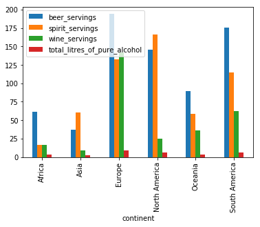

```python
drinks.groupby('continent').mean().plot(kind='bar')
```

#### Lecture 15

How do I explore a Pandas Series?

```python
movies=pd.read_csv('http://bit.ly/imdbratings')
```

```python
movies.head()
```

|  | star_rating | title | content_rating | genre | duration | actors_list |
| --- | --- | --- | --- | --- | --- | --- |
| 0 | 9.3 | The Shawshank Redemption | R | Crime | 142 | [u'Tim Robbins', u'Morgan Freeman', u'Bob Gunt... |
| 1 | 9.2 | The Godfather | R | Crime | 175 | [u'Marlon Brando', u'Al Pacino', u'James Caan'] |
| 2 | 9.1 | The Godfather: Part II | R | Crime | 200 | [u'Al Pacino', u'Robert De Niro', u'Robert Duv... |
| 3 | 9.0 | The Dark Knight | PG-13 | Action | 152 | [u'Christian Bale', u'Heath Ledger', u'Aaron E... |
| 4 | 8.9 | Pulp Fiction | R | Crime | 154 | [u'John Travolta', u'Uma Thurman', u'Samuel L.... |

```python
movies.dtypes
```

```
star_rating       float64
title              object
content_rating     object
genre              object
duration            int64
actors_list        object
dtype: object
```

```python
movies.genre.describe()
```

```
count       979
unique       16
top       Drama
freq        278
Name: genre, dtype: object
```

```python
movies.genre.value_counts()
```

```
Drama        278
Comedy       156
Action       136
Crime        124
Biography     77
Adventure     75
Animation     62
Horror        29
Mystery       16
Western        9
Thriller       5
Sci-Fi         5
Film-Noir      3
Family         2
History        1
Fantasy        1
Name: genre, dtype: int64
```

```python
movies.genre.value_counts(normalize=True)
```

```
Drama        0.283963
Comedy       0.159346
Action       0.138917
Crime        0.126660
Biography    0.078652
Adventure    0.076609
Animation    0.063330
Horror       0.029622
Mystery      0.016343
Western      0.009193
Thriller     0.005107
Sci-Fi       0.005107
Film-Noir    0.003064
Family       0.002043
History      0.001021
Fantasy      0.001021
Name: genre, dtype: float64
```

```python
pd.crosstab(movies.genre,movies.content_rating)
```

| content_rating genre | APPROVED | G | GP | NC-17 | NOT RATED | PASSED | PG | PG-13 | R | TV-MA | UNRATED | X |
| --- | --- | --- | --- | --- | --- | --- | --- | --- | --- | --- | --- | --- |
| Action | 3 | 1 | 1 | 0 | 4 | 1 | 11 | 44 | 67 | 0 | 3 | 0 |
| Adventure | 3 | 2 | 0 | 0 | 5 | 1 | 21 | 23 | 17 | 0 | 2 | 0 |
| Animation | 3 | 20 | 0 | 0 | 3 | 0 | 25 | 5 | 5 | 0 | 1 | 0 |
| Biography | 1 | 2 | 1 | 0 | 1 | 0 | 6 | 29 | 36 | 0 | 0 | 0 |
| Comedy | 9 | 2 | 1 | 1 | 16 | 3 | 23 | 23 | 73 | 0 | 4 | 1 |
| Crime | 6 | 0 | 0 | 1 | 7 | 1 | 6 | 4 | 87 | 0 | 11 | 1 |
| Drama | 12 | 3 | 0 | 4 | 24 | 1 | 25 | 55 | 143 | 1 | 9 | 1 |
| Family | 0 | 1 | 0 | 0 | 0 | 0 | 1 | 0 | 0 | 0 | 0 | 0 |
| Fantasy | 0 | 0 | 0 | 0 | 0 | 0 | 0 | 0 | 1 | 0 | 0 | 0 |
| Film-Noir | 1 | 0 | 0 | 0 | 1 | 0 | 0 | 0 | 0 | 0 | 1 | 0 |
| History | 0 | 0 | 0 | 0 | 0 | 0 | 0 | 0 | 0 | 0 | 1 | 0 |
| Horror | 2 | 0 | 0 | 1 | 1 | 0 | 1 | 2 | 16 | 0 | 5 | 1 |
| Mystery | 4 | 1 | 0 | 0 | 1 | 0 | 1 | 2 | 6 | 0 | 1 | 0 |
| Sci-Fi | 1 | 0 | 0 | 0 | 0 | 0 | 0 | 1 | 3 | 0 | 0 | 0 |
| Thriller | 1 | 0 | 0 | 0 | 0 | 0 | 1 | 0 | 3 | 0 | 0 | 0 |
| Western | 1 | 0 | 0 | 0 | 2 | 0 | 2 | 1 | 3 | 0 | 0 | 0 |

```python
movies.duration.describe()
```

```
count    979.000000
mean     120.979571
std       26.218010
min       64.000000
25%      102.000000
50%      117.000000
75%      134.000000
max      242.000000
Name: duration, dtype: float64
```

```python
movies.duration.mean()
```

```
120.97957099080695
```

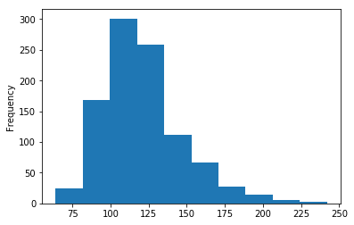

```python
movies.duration.plot(kind="hist")
```

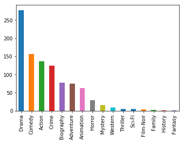

```python
movies.genre.value_counts().plot(kind="bar")
```

#### Lecture 16

How do I handle missing values in Pandas?

```python
ufo=pd.read_csv('http://bit.ly/uforeports')
```

```python
ufo.tail()
```

|  | City | Colors Reported | Shape Reported | State | Time |
| --- | --- | --- | --- | --- | --- |
| 18236 | Grant Park | NaN | TRIANGLE | IL | 12/31/2000 23:00 |
| 18237 | Spirit Lake | NaN | DISK | IA | 12/31/2000 23:00 |
| 18238 | Eagle River | NaN | NaN | WI | 12/31/2000 23:45 |
| 18239 | Eagle River | RED | LIGHT | WI | 12/31/2000 23:45 |
| 18240 | Ybor | NaN | OVAL | FL | 12/31/2000 23:59 |

```python
ufo.isnull().tail()
```

|  | City | Colors Reported | Shape Reported | State | Time |
| --- | --- | --- | --- | --- | --- |
| 18236 | False | True | False | False | False |
| 18237 | False | True | False | False | False |
| 18238 | False | True | True | False | False |
| 18239 | False | False | False | False | False |
| 18240 | False | True | False | False | False |

```python
ufo.isnull().sum()
```

```
City                  25
Colors Reported    15359
Shape Reported      2644
State                  0
Time                   0
dtype: int64
```

By default it will show the column sum

```python
ufo[ufo.City.isnull()].head()
```

|  | City | Colors Reported | Shape Reported | State | Time |
| --- | --- | --- | --- | --- | --- |
| 21 | NaN | NaN | NaN | LA | 8/15/1943 0:00 |
| 22 | NaN | NaN | LIGHT | LA | 8/15/1943 0:00 |
| 204 | NaN | NaN | DISK | CA | 7/15/1952 12:30 |
| 241 | NaN | BLUE | DISK | MT | 7/4/1953 14:00 |
| 613 | NaN | NaN | DISK | NV | 7/1/1960 12:00 |

```python
ufo.shape
```

```
(18241, 5)
```

```python
ufo.dropna(how="any").shape
```

```
(2486, 5)
```

```python
ufo.dropna(how="all").shape
```

```
(18241, 5)
```

```python
ufo['Shape Reported'].describe()
```

```
count     15597
unique       27
top       LIGHT
freq       2803
Name: Shape Reported, dtype: object
```

```python
ufo['Shape Reported'].value_counts(dropna=False).head()
```

```
LIGHT       2803
NaN         2644
DISK        2122
TRIANGLE    1889
OTHER       1402
Name: Shape Reported, dtype: int64
```

```python
ufo['Shape Reported'].fillna(value="VARIOUS",inplace=True)
```

```python
ufo['Shape Reported'].value_counts().head()
```

```
VARIOUS     2977
LIGHT       2803
DISK        2122
TRIANGLE    1889
OTHER       1402
Name: Shape Reported, dtype: int64
```

#### Lecture 17

What do i need to know about the pandas index?

```python
drinks=pd.read_csv('http://bit.ly/drinksbycountry')
```

```python
drinks.head()
```

|  | country | beer_servings | spirit_servings | wine_servings | total_litres_of_pure_alcohol | continent |
| --- | --- | --- | --- | --- | --- | --- |
| 0 | Afghanistan | 0 | 0 | 0 | 0.0 | Asia |
| 1 | Albania | 89 | 132 | 54 | 4.9 | Europe |
| 2 | Algeria | 25 | 0 | 14 | 0.7 | Africa |
| 3 | Andorra | 245 | 138 | 312 | 12.4 | Europe |
| 4 | Angola | 217 | 57 | 45 | 5.9 | Africa |

```python
drinks.index
```

```
RangeIndex(start=0, stop=193, step=1)
```

```python
drinks.columns
```

```
Index(['country', 'beer_servings', 'spirit_servings', 'wine_servings',
       'total_litres_of_pure_alcohol', 'continent'],
      dtype='object')
```

```python
drinks.shape
```

```
(193, 6)
```

```python
pd.read_table('http://bit.ly/movieusers',header=None,sep='|').head()
```

|  | 0 | 1 | 2 | 3 | 4 |
| --- | --- | --- | --- | --- | --- |
| 0 | 1 | 24 | M | technician | 85711 |
| 1 | 2 | 53 | F | other | 94043 |
| 2 | 3 | 23 | M | writer | 32067 |
| 3 | 4 | 24 | M | technician | 43537 |
| 4 | 5 | 33 | F | other | 15213 |

What is the index used for?

1. Identification
2. Selection
3. Alignment

```python
drinks[drinks.continent=='South America']
```

|  | country | beer_servings | spirit_servings | wine_servings | total_litres_of_pure_alcohol | continent |
| --- | --- | --- | --- | --- | --- | --- |
| 6 | Argentina | 193 | 25 | 221 | 8.3 | South America |
| 20 | Bolivia | 167 | 41 | 8 | 3.8 | South America |
| 23 | Brazil | 245 | 145 | 16 | 7.2 | South America |
| 35 | Chile | 130 | 124 | 172 | 7.6 | South America |
| 37 | Colombia | 159 | 76 | 3 | 4.2 | South America |
| 52 | Ecuador | 162 | 74 | 3 | 4.2 | South America |
| 72 | Guyana | 93 | 302 | 1 | 7.1 | South America |
| 132 | Paraguay | 213 | 117 | 74 | 7.3 | South America |
| 133 | Peru | 163 | 160 | 21 | 6.1 | South America |
| 163 | Suriname | 128 | 178 | 7 | 5.6 | South America |
| 185 | Uruguay | 115 | 35 | 220 | 6.6 | South America |
| 188 | Venezuela | 333 | 100 | 3 | 7.7 | South America |

```python
drinks.loc[23,'beer_servings']
```

```
245
```

#### Lecture 18

How do I select multiple rows and columns from a pandas DataFrame?

```python
ufo=pd.read_csv('http://bit.ly/uforeports')
```

```python
ufo.head(3)
```

|  | City | Colors Reported | Shape Reported | State | Time |
| --- | --- | --- | --- | --- | --- |
| 0 | Ithaca | NaN | TRIANGLE | NY | 6/1/1930 22:00 |
| 1 | Willingboro | NaN | OTHER | NJ | 6/30/1930 20:00 |
| 2 | Holyoke | NaN | OVAL | CO | 2/15/1931 14:00 |

```python
ufo.loc[0,:]
```

```
City                       Ithaca
Colors Reported               NaN
Shape Reported           TRIANGLE
State                          NY
Time               6/1/1930 22:00
Name: 0, dtype: object
```

```python
ufo.loc[[0,1,2],:]
```

|  | City | Colors Reported | Shape Reported | State | Time |
| --- | --- | --- | --- | --- | --- |
| 0 | Ithaca | NaN | TRIANGLE | NY | 6/1/1930 22:00 |
| 1 | Willingboro | NaN | OTHER | NJ | 6/30/1930 20:00 |
| 2 | Holyoke | NaN | OVAL | CO | 2/15/1931 14:00 |

```python
ufo.loc[0:3,:]
```

|  | City | Colors Reported | Shape Reported | State | Time |
| --- | --- | --- | --- | --- | --- |
| 0 | Ithaca | NaN | TRIANGLE | NY | 6/1/1930 22:00 |
| 1 | Willingboro | NaN | OTHER | NJ | 6/30/1930 20:00 |
| 2 | Holyoke | NaN | OVAL | CO | 2/15/1931 14:00 |
| 3 | Abilene | NaN | DISK | KS | 6/1/1931 13:00 |

```python
ufo.loc[0:2]
```

|  | City | Colors Reported | Shape Reported | State | Time |
| --- | --- | --- | --- | --- | --- |
| 0 | Ithaca | NaN | TRIANGLE | NY | 6/1/1930 22:00 |
| 1 | Willingboro | NaN | OTHER | NJ | 6/30/1930 20:00 |
| 2 | Holyoke | NaN | OVAL | CO | 2/15/1931 14:00 |

```python
ufo.loc[0:2,'City']
```

```
0         Ithaca
1    Willingboro
2        Holyoke
Name: City, dtype: object
```

```python
ufo.loc[0:2,['City','State']]
```

|  | City | State |
| --- | --- | --- |
| 0 | Ithaca | NY |
| 1 | Willingboro | NJ |
| 2 | Holyoke | CO |

```python
ufo[['City','State']].head(3)
```

|  | City | State |
| --- | --- | --- |
| 0 | Ithaca | NY |
| 1 | Willingboro | NJ |
| 2 | Holyoke | CO |

```python
ufo.loc[0:2,'City':'State']
```

|  | City | Colors Reported | Shape Reported | State |
| --- | --- | --- | --- | --- |
| 0 | Ithaca | NaN | TRIANGLE | NY |
| 1 | Willingboro | NaN | OTHER | NJ |
| 2 | Holyoke | NaN | OVAL | CO |

```python
ufo.head(3).drop('Time',axis=1)
```

|  | City | Colors Reported | Shape Reported | State |
| --- | --- | --- | --- | --- |
| 0 | Ithaca | NaN | TRIANGLE | NY |
| 1 | Willingboro | NaN | OTHER | NJ |
| 2 | Holyoke | NaN | OVAL | CO |

```python
ufo[ufo.City=='Oakland'].State
```

```
1694     CA
2144     CA
4686     MD
7293     CA
8488     CA
8768     CA
10816    OR
10948    CA
11045    CA
12322    CA
12941    CA
16803    MD
17322    CA
Name: State, dtype: object
```

#### Lecture 19

When should I use the "inplace" parameter in pandas?

```python
ufo=pd.read_csv('http://bit.ly/uforeports')
```

```python
ufo.head()
```

|  | City | Colors Reported | Shape Reported | State | Time |
| --- | --- | --- | --- | --- | --- |
| 0 | Ithaca | NaN | TRIANGLE | NY | 6/1/1930 22:00 |
| 1 | Willingboro | NaN | OTHER | NJ | 6/30/1930 20:00 |
| 2 | Holyoke | NaN | OVAL | CO | 2/15/1931 14:00 |
| 3 | Abilene | NaN | DISK | KS | 6/1/1931 13:00 |
| 4 | New York Worlds Fair | NaN | LIGHT | NY | 4/18/1933 19:00 |

```python
ufo.shape
```

```
(18241, 5)
```

```python
ufo.drop('City',axis=1).head()
```

|  | Colors Reported | Shape Reported | State | Time |
| --- | --- | --- | --- | --- |
| 0 | NaN | TRIANGLE | NY | 6/1/1930 22:00 |
| 1 | NaN | OTHER | NJ | 6/30/1930 20:00 |
| 2 | NaN | OVAL | CO | 2/15/1931 14:00 |
| 3 | NaN | DISK | KS | 6/1/1931 13:00 |
| 4 | NaN | LIGHT | NY | 4/18/1933 19:00 |

```python
ufo.drop('City',axis=1).head()
```

|  | Colors Reported | Shape Reported | State | Time |
| --- | --- | --- | --- | --- |
| 0 | NaN | TRIANGLE | NY | 6/1/1930 22:00 |
| 1 | NaN | OTHER | NJ | 6/30/1930 20:00 |
| 2 | NaN | OVAL | CO | 2/15/1931 14:00 |
| 3 | NaN | DISK | KS | 6/1/1931 13:00 |
| 4 | NaN | LIGHT | NY | 4/18/1933 19:00 |

```python
ufo.head()
```

|  | City | Colors Reported | Shape Reported | State | Time |
| --- | --- | --- | --- | --- | --- |
| 0 | Ithaca | NaN | TRIANGLE | NY | 6/1/1930 22:00 |
| 1 | Willingboro | NaN | OTHER | NJ | 6/30/1930 20:00 |
| 2 | Holyoke | NaN | OVAL | CO | 2/15/1931 14:00 |
| 3 | Abilene | NaN | DISK | KS | 6/1/1931 13:00 |
| 4 | New York Worlds Fair | NaN | LIGHT | NY | 4/18/1933 19:00 |

```python
ufo.head()
```

|  | City | Colors Reported | Shape Reported | State | Time |
| --- | --- | --- | --- | --- | --- |
| 0 | Ithaca | NaN | TRIANGLE | NY | 6/1/1930 22:00 |
| 1 | Willingboro | NaN | OTHER | NJ | 6/30/1930 20:00 |
| 2 | Holyoke | NaN | OVAL | CO | 2/15/1931 14:00 |
| 3 | Abilene | NaN | DISK | KS | 6/1/1931 13:00 |
| 4 | New York Worlds Fair | NaN | LIGHT | NY | 4/18/1933 19:00 |

```python
ufo.drop('City',axis=1,inplace=True)
```

```python
ufo.head()
```

|  | Colors Reported | Shape Reported | State | Time |
| --- | --- | --- | --- | --- |
| 0 | NaN | TRIANGLE | NY | 6/1/1930 22:00 |
| 1 | NaN | OTHER | NJ | 6/30/1930 20:00 |
| 2 | NaN | OVAL | CO | 2/15/1931 14:00 |
| 3 | NaN | DISK | KS | 6/1/1931 13:00 |
| 4 | NaN | LIGHT | NY | 4/18/1933 19:00 |

```python
ufo.dropna(how="any").shape
```

```
(2490, 4)
```

```python
ufo=ufo.set_index('Time')
```

```python
ufo.tail()
```

| Time | Colors Reported | Shape Reported | State |
| --- | --- | --- | --- |
| 12/31/2000 23:00 | NaN | TRIANGLE | IL |
| 12/31/2000 23:00 | NaN | DISK | IA |
| 12/31/2000 23:45 | NaN | NaN | WI |
| 12/31/2000 23:45 | RED | LIGHT | WI |
| 12/31/2000 23:59 | NaN | OVAL | FL |

```python
ufo.fillna(method='bfill').tail()
```

| Time | Colors Reported | Shape Reported | State |
| --- | --- | --- | --- |
| 12/31/2000 23:00 | RED | TRIANGLE | IL |
| 12/31/2000 23:00 | RED | DISK | IA |
| 12/31/2000 23:45 | RED | LIGHT | WI |
| 12/31/2000 23:45 | RED | LIGHT | WI |
| 12/31/2000 23:59 | NaN | OVAL | FL |

```python
ufo.fillna(method="ffill").tail()
```

| Time | Colors Reported | Shape Reported | State |
| --- | --- | --- | --- |
| 12/31/2000 23:00 | RED | TRIANGLE | IL |
| 12/31/2000 23:00 | RED | DISK | IA |
| 12/31/2000 23:45 | RED | DISK | WI |
| 12/31/2000 23:45 | RED | LIGHT | WI |
| 12/31/2000 23:59 | RED | OVAL | FL |

#### Lecture 20

How do I make my pandas DataFrame smaller and faster?

```python
drinks=pd.read_csv('http://bit.ly/drinksbycountry')
```

```python
drinks.head()
```

|  | country | beer_servings | spirit_servings | wine_servings | total_litres_of_pure_alcohol | continent |
| --- | --- | --- | --- | --- | --- | --- |
| 0 | Afghanistan | 0 | 0 | 0 | 0.0 | Asia |
| 1 | Albania | 89 | 132 | 54 | 4.9 | Europe |
| 2 | Algeria | 25 | 0 | 14 | 0.7 | Africa |
| 3 | Andorra | 245 | 138 | 312 | 12.4 | Europe |
| 4 | Angola | 217 | 57 | 45 | 5.9 | Africa |

```python
drinks.info()
```

```
<class 'pandas.core.frame.DataFrame'>
RangeIndex: 193 entries, 0 to 192
Data columns (total 6 columns):
country                         193 non-null object
beer_servings                   193 non-null int64
spirit_servings                 193 non-null int64
wine_servings                   193 non-null int64
total_litres_of_pure_alcohol    193 non-null float64
continent                       193 non-null object
dtypes: float64(1), int64(3), object(2)
memory usage: 9.1+ KB
```

```python
drinks.info(memory_usage='deep')
```

```
<class 'pandas.core.frame.DataFrame'>
RangeIndex: 193 entries, 0 to 192
Data columns (total 6 columns):
country                         193 non-null object
beer_servings                   193 non-null int64
spirit_servings                 193 non-null int64
wine_servings                   193 non-null int64
total_litres_of_pure_alcohol    193 non-null float64
continent                       193 non-null object
dtypes: float64(1), int64(3), object(2)
memory usage: 30.4 KB
```

```python
drinks.memory_usage(deep=True)
```

```
Index                              80
country                         12588
beer_servings                    1544
spirit_servings                  1544
wine_servings                    1544
total_litres_of_pure_alcohol     1544
continent                       12332
dtype: int64
```

```python
drinks['continent']=drinks.continent.astype('category')
```

```python
drinks.continent.head()
```

```
0      Asia
1    Europe
2    Africa
3    Europe
4    Africa
Name: continent, dtype: category
Categories (6, object): [Africa, Asia, Europe, North America, Oceania, South America]
```

```python
drinks.memory_usage(deep=True)
```

```
Index                              80
country                         12588
beer_servings                    1544
spirit_servings                  1544
wine_servings                    1544
total_litres_of_pure_alcohol     1544
continent                         744
dtype: int64
```

```python
df=pd.DataFrame({'ID':[100,101,102,103],'quality':['good','very good','good','excellent']})
```

```python
df
```

|  | ID | quality |
| --- | --- | --- |
| 0 | 100 | good |
| 1 | 101 | very good |
| 2 | 102 | good |
| 3 | 103 | excellent |

```python
df.sort_values('quality')
```

|  | ID | quality |
| --- | --- | --- |
| 3 | 103 | excellent |
| 0 | 100 | good |
| 2 | 102 | good |
| 1 | 101 | very good |

```python
df.loc[df.quality>'good',:]
```

|  | ID | quality |
| --- | --- | --- |
| 1 | 101 | very good |

#### Lceture 22

How do I use pandas with scikit-learn to create Kaggle Submission?

```python
train=pd.read_csv('http://bit.ly/kaggletrain')
```

```python
train.head()
```

|  | PassengerId | Survived | Pclass | Name | Sex | Age | SibSp | Parch | Ticket | Fare | Cabin | Embarked |
| --- | --- | --- | --- | --- | --- | --- | --- | --- | --- | --- | --- | --- |
| 0 | 1 | 0 | 3 | Braund, Mr. Owen Harris | male | 22.0 | 1 | 0 | A/5 21171 | 7.2500 | NaN | S |
| 1 | 2 | 1 | 1 | Cumings, Mrs. John Bradley (Florence Briggs Th... | female | 38.0 | 1 | 0 | PC 17599 | 71.2833 | C85 | C |
| 2 | 3 | 1 | 3 | Heikkinen, Miss. Laina | female | 26.0 | 0 | 0 | STON/O2. 3101282 | 7.9250 | NaN | S |
| 3 | 4 | 1 | 1 | Futrelle, Mrs. Jacques Heath (Lily May Peel) | female | 35.0 | 1 | 0 | 113803 | 53.1000 | C123 | S |
| 4 | 5 | 0 | 3 | Allen, Mr. William Henry | male | 35.0 | 0 | 0 | 373450 | 8.0500 | NaN | S |

```python
feature_cols=['Pclass','Parch']
```

```python
x=train.loc[:,feature_cols]
```

```python
x.shape
```

```
(891, 2)
```

```python
from sklearn.linear_model import LogisticRegression
```

```python
y=train.Survived
logreg = LogisticRegression()
logreg.fit(x, y)
```

```
LogisticRegression(C=1.0, class_weight=None, dual=False, fit_intercept=True,
          intercept_scaling=1, max_iter=100, multi_class='ovr', n_jobs=1,
          penalty='l2', random_state=None, solver='liblinear', tol=0.0001,
          verbose=0, warm_start=False)
```

```python
test=pd.read_csv('http://bit.ly/kaggletest')
```

```python
test.head()
```

|  | PassengerId | Pclass | Name | Sex | Age | SibSp | Parch | Ticket | Fare | Cabin | Embarked |
| --- | --- | --- | --- | --- | --- | --- | --- | --- | --- | --- | --- |
| 0 | 892 | 3 | Kelly, Mr. James | male | 34.5 | 0 | 0 | 330911 | 7.8292 | NaN | Q |
| 1 | 893 | 3 | Wilkes, Mrs. James (Ellen Needs) | female | 47.0 | 1 | 0 | 363272 | 7.0000 | NaN | S |
| 2 | 894 | 2 | Myles, Mr. Thomas Francis | male | 62.0 | 0 | 0 | 240276 | 9.6875 | NaN | Q |
| 3 | 895 | 3 | Wirz, Mr. Albert | male | 27.0 | 0 | 0 | 315154 | 8.6625 | NaN | S |
| 4 | 896 | 3 | Hirvonen, Mrs. Alexander (Helga E Lindqvist) | female | 22.0 | 1 | 1 | 3101298 | 12.2875 | NaN | S |

```python
X_new=test.loc[:,feature_cols]
```

```python
X_new.shape
```

```
(418, 2)
```

```python
new_pred_class=logreg.predict(X_new)
```

```python
pd.DataFrame({'PassengerId':test.PassengerId, 'Survived':new_pred_class}).head()
```

|  | PassengerId | Survived |
| --- | --- | --- |
| 0 | 892 | 0 |
| 1 | 893 | 0 |
| 2 | 894 | 0 |
| 3 | 895 | 0 |
| 4 | 896 | 0 |

```python
pd.DataFrame({'PassengerId':test.PassengerId, 'Survived':new_pred_class}).set_index('PassengerId').to_csv('sub.csv')
```